# Week12

In terms of feature engineering, we decided to create a feature called birthweight.cat, which divided birthweights into the categories (based on medical literature) of “Normal”, “Low”, “Very Low”, and “Extremely Low.” Below, we see that a graph of charges distribution as a function of these categories shows clearer separation of charge distributions than birthweight or severity alone (the median birth charge is shown as a blue dashed line). Thus, we expect this feature to be a good predictor of charges.

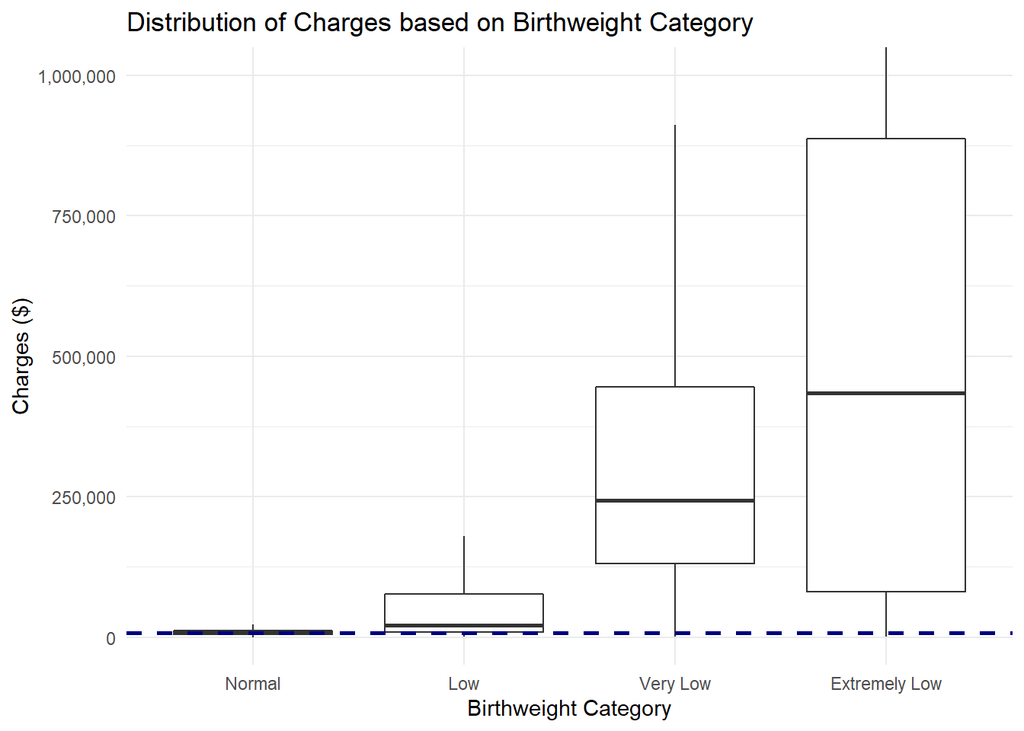

```r
# Engineered feature to create birthweight cutoffs (birthweight.cat) (see reference 2)
hosp <- hosp %>%
  mutate(birthweight.cat = case_when(
    Birthweight < 2500 & Birthweight > 1500 ~ "Low",
    Birthweight <= 1500 & Birthweight > 1000 ~ "Very Low",
    Birthweight <= 1000 ~ "Extremely Low",
    TRUE ~ "Normal"
  ))
# reinitialize births df
births <- hosp[hosp$Birthweight>0 & !is.na(hosp$Birthweight),]

# graph birthweight.cat vs. charges
ggplot(births, aes(x=birthweight.cat, y=Charges)) +
  geom_boxplot(outlier.shape=NA) +
  coord_cartesian(ylim=c(0,1000000)) +
  ggtitle("Distribution of Charges based on Birthweight Category") +
  xlab("Birthweight Category") +
  ylab("Charges ($)") +
  scale_x_discrete(limits=c("Normal", "Low", "Very Low", "Extremely Low")) +
  scale_y_continuous(labels=scales::comma) +
  geom_hline(yintercept=median(births$Charges), size=1, linetype="dashed", color="navy blue")
```

We also created a feature called charge ratio, defined as the total charges (amount billed to the consumer) divided by the costs (amount the hospital spent while taking care of you).

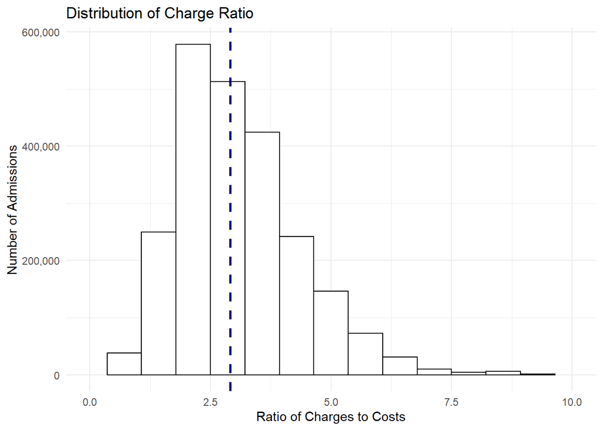

```r
# create charge ratio variable
hosp$chargeratio <- hosp$Charges / hosp$Costs

# graph distribution of chargeratio
ggplot(hosp, aes(x=chargeratio)) +
  geom_histogram(bins=15, fill="white", color="black") +
  xlim(0,10) +
  geom_vline(xintercept=median(hosp$chargeratio),
             linetype="dashed", color="navy blue", size=1) +
  xlab("Ratio of Charges to Costs") +
  ylab("Number of Admissions") +
  ggtitle("Distribution of Charge Ratio") +
  scale_y_continuous(labels=scales::comma) # note removal of rows due to 0 cost or 0 charge
```

Above, we see that the distribution of charge ratio is obviously right-skewed, with a median of around 2.9 (indicated by the dark blue dashed line).

However, in investigating charge distribution with the below plot, we noticed a strange, straight line with a higher slope than the rest of the data. To see if this indicating an abnormality in the data, we attempted to isolate the datapoints causing that trend by performing sequential filtering of the dataset.

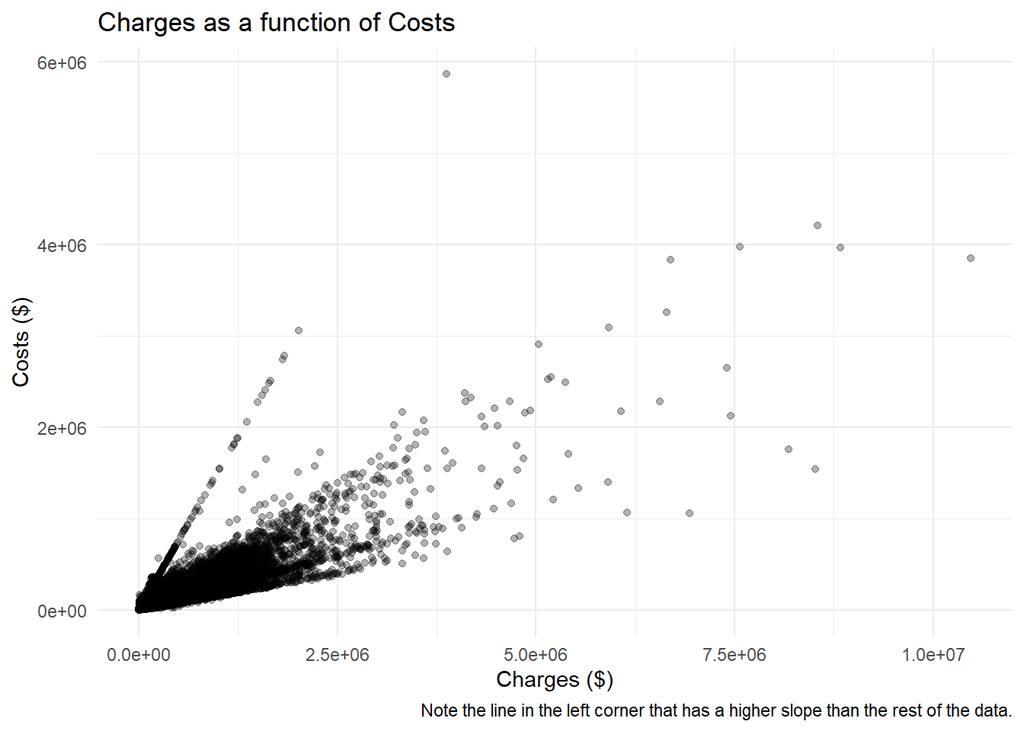

```r
# plot charges vs. costs
ggplot(hosp, aes(x=Charges, y=Costs)) +
  geom_point(alpha=.3) +
  ggtitle("Charges as a function of Costs") +
  xlab("Charges ($)") +
  ylab("Costs ($)") +
  labs(caption="Note the line in the left corner that has a higher slope than the rest of the data.")
```

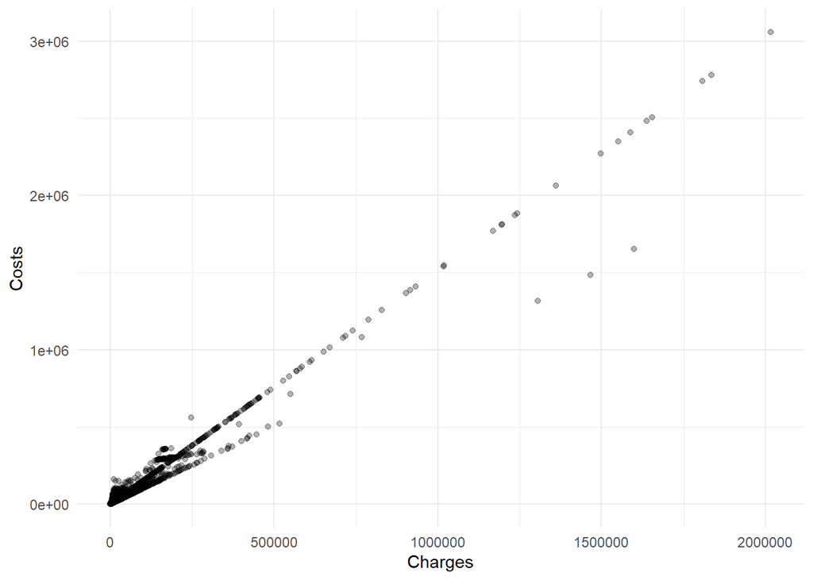

```r
# sequential filtering of the dataset
# 1. filter by charges < 2,500,000 and chargeratio < 1
temp <- hosp %>%
  filter(Charges < 2500000) %>%
  filter(chargeratio < 1)
# examine new plot
ggplot(temp, aes(x=Charges, y=Costs)) +
  geom_point(alpha=.3)
```

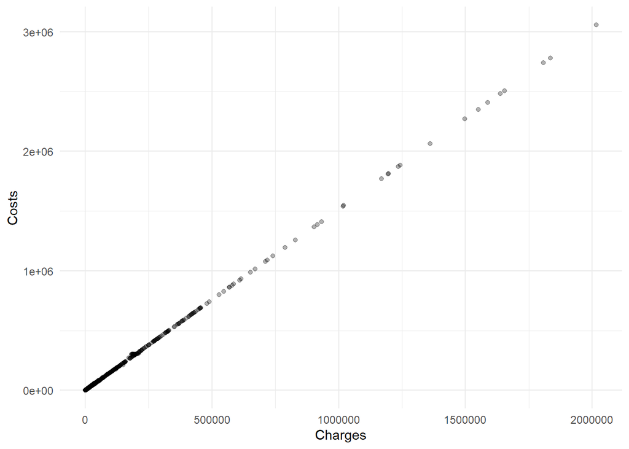

```r
# 2. From inspection, the slope of the line appears to be 3/2 cost/charge, or 2/3 charge/cost. Thus, we filter by chargeratio between .7 and .6.
temptemp <- temp %>%
  filter(chargeratio < .7 & chargeratio > .6)
# examine new plots
ggplot(temptemp, aes(x=Charges, y=Costs)) +
  geom_point(alpha=.3)
```

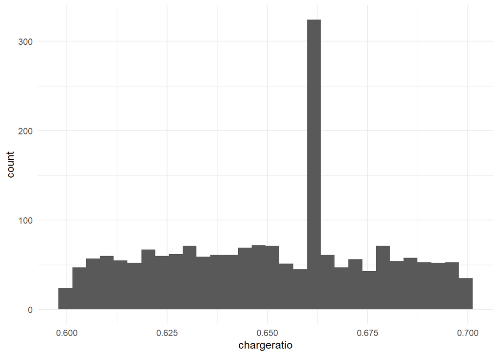

```r
ggplot(temptemp, aes(x=chargeratio)) +
  geom_histogram() # the sharp spike in the histogram represents the data we want to isolate
```

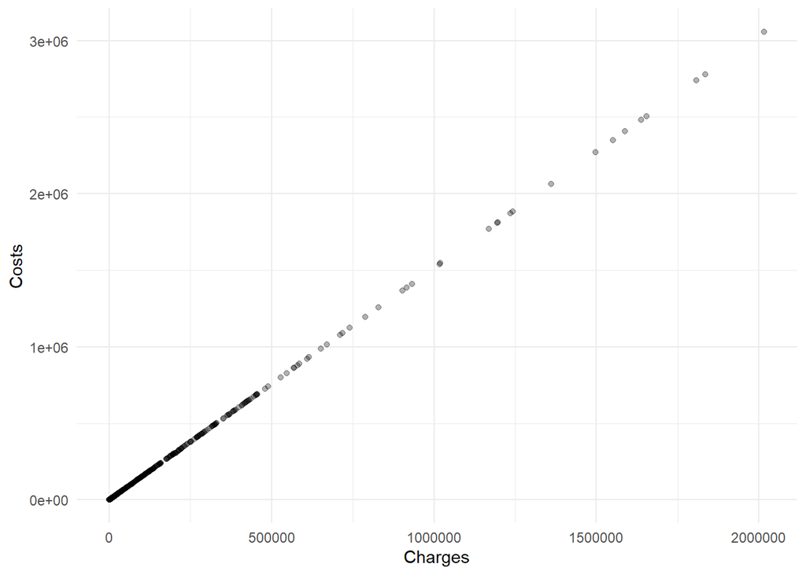

```r
# 3. Based on the spike, filter between .675 and .65 chargeratio
temptemptemp <- temptemp %>%
  filter(chargeratio < .675 & chargeratio > .65)
ggplot(temptemptemp, aes(x=Charges, y=Costs)) +
  geom_point(alpha=.3)
```

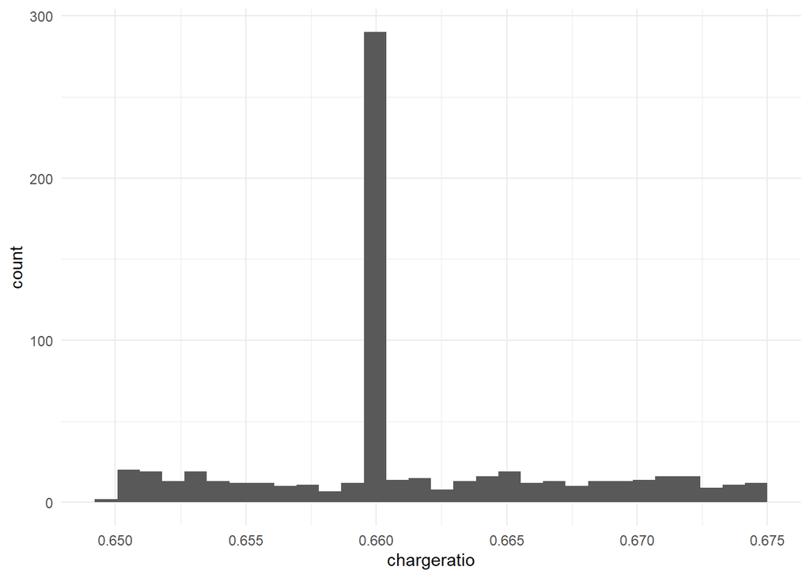

```r
ggplot(temptemptemp, aes(x=chargeratio)) +
  geom_histogram()
```